# Exploring Bay Wheels Rides Data

### Scatter Plot of Start Hour and Duration For Bike Share For All Trip

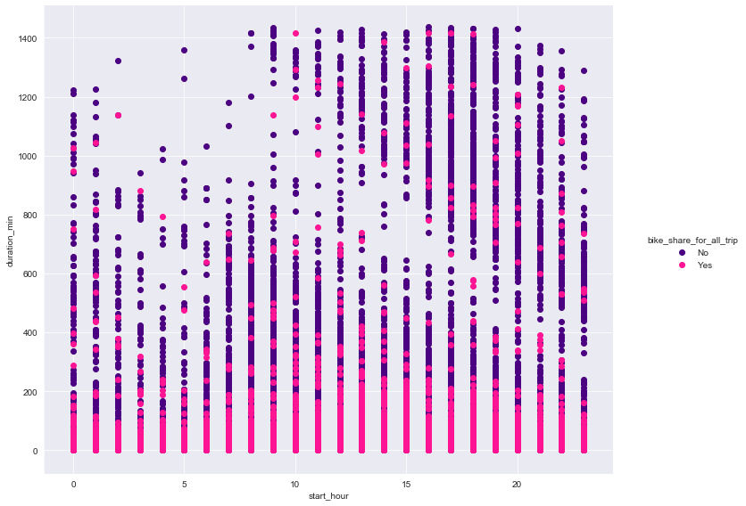

```python
g = sns.FacetGrid(data=bay_wheels, hue='bike_share_for_all_trip', palette=['indigo','deeppink'], height=8)
g.map(plt.scatter, 'start_hour', 'duration_min')
g.add_legend()
g.fig.set_size_inches(12,8);
```

### Point Plot of Ride Duration and Month For Each User Type

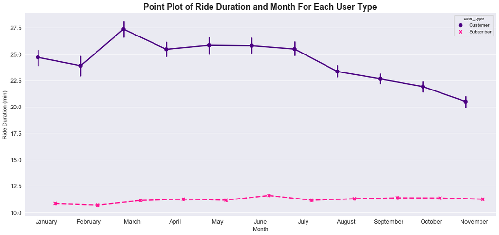

```python
plt.figure(figsize=([18,8]))
sns.pointplot(data=bay_wheels, x='start_month', y='duration_min', hue='user_type', palette=['indigo','deeppink'], markers=["o","x"],linestyles=["-", "--"], dodge=0.4)
plt.xlabel('Month',fontsize=12)
plt.ylabel('Ride Duration (min)',fontsize=12)
plt.xticks(fontsize=13)
plt.yticks(fontsize=13)
plt.title('Point Plot of Ride Duration and Month For Each User Type', fontsize=18, weight='bold');
```

**Observation**

- Customer are more likely to ride for longer time than subscriber.

### Point Plot of Ride Distance and Month For Each User Type

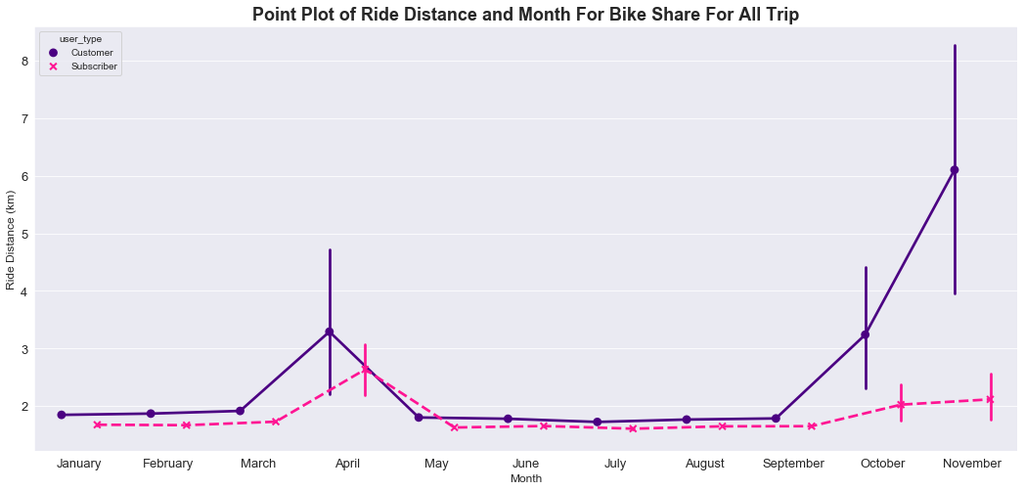

```python
plt.figure(figsize=([18,8]))
sns.pointplot(data=bay_wheels, x='start_month', y='distance_km', hue='user_type', palette=['indigo','deeppink'], markers=["o","x"], linestyles=["-", "--"], dodge=0.4)
plt.xlabel('Month',fontsize=12)
plt.ylabel('Ride Distance (km)',fontsize=12)
plt.xticks(fontsize=13)
plt.yticks(fontsize=13)
plt.title('Point Plot of Ride Distance and Month For Bike Share For All Trip', fontsize=18, weight='bold');
```

**Observation**

- Customer are more likely to ride for longer distance than subscriber.

## Conclusion From Multivariate Exploration

I observed that subscriber ride more in the morning around 8 am and ride less in evening. And customer ride more in evening and less in morning.

## Interesting or surprising relation between features

- In morning subscriber ride for longer distance than customer.
- In evening customer ride for longer distance than subscriber.